# SR_04_RLTD_ORG_CORP_PCT_OWN

Percentage ownership · Number report

## Overview

**Description**

Percentage ownership

**Table**

`SR-P04-T01-ID-RLTD-ORGS-TAXABLE-CORPORATION` (many)

**Location code**

`SCHED-R-PART-04-COL-H`

**Family**

`SCHED-R-PART-04-COL-H`

**Data type**

numeric (xsd: RatioType)

**Scope**

PC

**Status**

unreviewed

2

xpaths mapped (2 observed)

98,417

filings with a value

2009–2024

tax years observed

2

open flags (0 errors)

## Flags

| Severity | Flag | Xpath | Detail |
| --- | --- | --- | --- |
| ⓘ info | `MANY_NOT_REPEATING` | IRS990ScheduleR/IdRelatedOrgTxblCorpTrGrp/OwnershipPct | many-to-one table, but 57% of values sit in no repeating element |
| ⓘ info | `MANY_NOT_REPEATING` | IRS990ScheduleR/Form990ScheduleRPartIV/PercentageOwnership | many-to-one table, but 53% of values sit in no repeating element |

## Xpaths

All mapped xpaths (under /Return/ReturnData or /Return/ReturnHeader), oldest first. Charts label each series by its xpath.

| Xpath | Form | First year | Last year | Versions | Filings | Repeats in |
| --- | --- | --- | --- | --- | --- | --- |
| IRS990ScheduleR/Form990ScheduleRPartIV/PercentageOwnership | Sched R | 2009 | 2012 | 16 | 18,789 | 39.1% |
| IRS990ScheduleR/IdRelatedOrgTxblCorpTrGrp/OwnershipPct | Sched R | 2013 | 2024 | 37 | 79,628 | 34.0% |

## Coverage

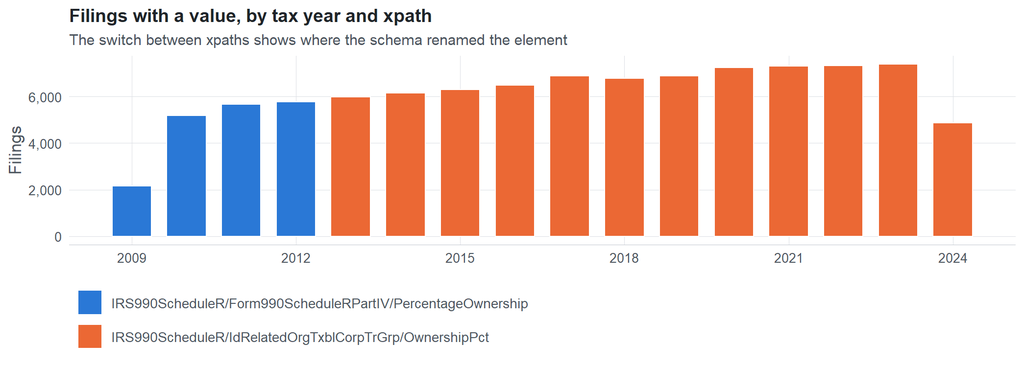

**Table view**

Table view: filings by tax year and series

| Tax year | IRS990ScheduleR/Form990ScheduleRPartIV/PercentageOwnership | IRS990ScheduleR/IdRelatedOrgTxblCorpTrGrp/OwnershipPct |
| --- | --- | --- |
| 2009 | 2,170 | 0 |
| 2010 | 5,178 | 0 |
| 2011 | 5,677 | 0 |
| 2012 | 5,764 | 0 |
| 2013 | 0 | 5,984 |
| 2014 | 0 | 6,155 |
| 2015 | 0 | 6,306 |
| 2016 | 0 | 6,483 |
| 2017 | 0 | 6,882 |
| 2018 | 0 | 6,791 |
| 2019 | 0 | 6,881 |
| 2020 | 0 | 7,247 |
| 2021 | 0 | 7,308 |
| 2022 | 0 | 7,335 |
| 2023 | 0 | 7,384 |
| 2024 | 0 | 4,872 |

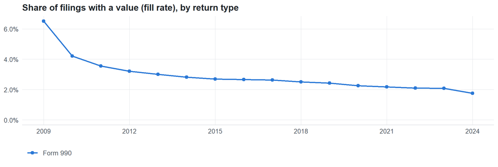

**Table view**

Table view: fill rate

| Tax year | Return type | Filings | All filings | Fill rate |
| --- | --- | --- | --- | --- |
| 2009 | Form 990 | 2,170 | 33,311 | 6.51% |
| 2010 | Form 990 | 5,178 | 123,025 | 4.21% |
| 2011 | Form 990 | 5,677 | 159,504 | 3.56% |
| 2012 | Form 990 | 5,764 | 179,688 | 3.21% |
| 2013 | Form 990 | 5,984 | 198,855 | 3.01% |
| 2014 | Form 990 | 6,155 | 218,619 | 2.82% |
| 2015 | Form 990 | 6,306 | 233,519 | 2.70% |
| 2016 | Form 990 | 6,483 | 243,903 | 2.66% |
| 2017 | Form 990 | 6,882 | 261,612 | 2.63% |
| 2018 | Form 990 | 6,791 | 271,442 | 2.50% |
| 2019 | Form 990 | 6,881 | 283,694 | 2.43% |
| 2020 | Form 990 | 7,247 | 320,342 | 2.26% |
| 2021 | Form 990 | 7,308 | 336,480 | 2.17% |
| 2022 | Form 990 | 7,335 | 349,055 | 2.10% |
| 2023 | Form 990 | 7,384 | 354,768 | 2.08% |
| 2024 | Form 990 | 4,872 | 277,298 | 1.76% |

## Repeating groups

Table cardinality in the concordance: **many**. 2 of 2 observed xpaths repeat within a filing.

Repeating element each xpath was observed in (from the raw indexed xpath)

| Xpath | Repeating element | Filings (summed over years) |
| --- | --- | --- |
| IRS990ScheduleR/Form990ScheduleRPartIV/PercentageOwnership | (none) | 10044 |
| IRS990ScheduleR/Form990ScheduleRPartIV/PercentageOwnership | IRS990ScheduleR/Form990ScheduleRPartIV | 8745 |
| IRS990ScheduleR/IdRelatedOrgTxblCorpTrGrp/OwnershipPct | (none) | 45640 |
| IRS990ScheduleR/IdRelatedOrgTxblCorpTrGrp/OwnershipPct | IRS990ScheduleR/IdRelatedOrgTxblCorpTrGrp | 33988 |

## Values

[output not shown]

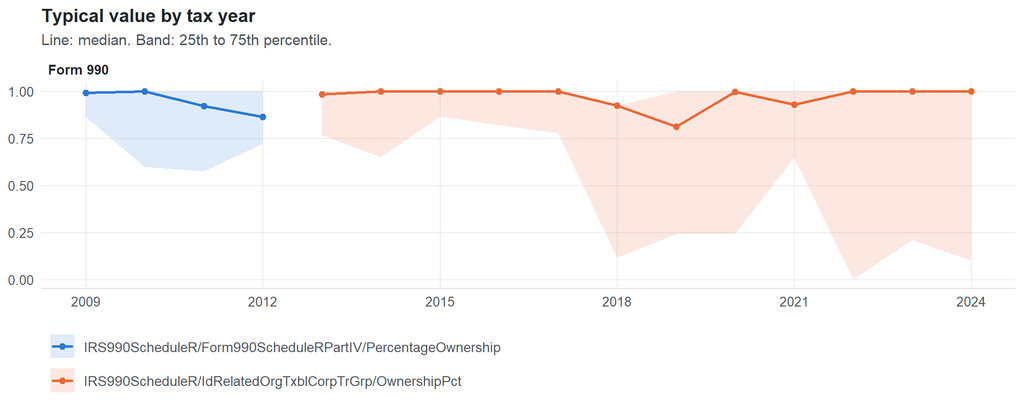

**Table view**

Table view: quartiles by tax year

[output not shown]

Summary by xpath and return type (all years)

| Series | Return | Filings | % numeric | % zero | % negative | Median (typical year) | P99 (typical year) |
| --- | --- | --- | --- | --- | --- | --- | --- |
| IRS990ScheduleR/Form990ScheduleRPartIV/PercentageOwnership | 990 | 18,789 | 100 | 18.98 | 0 | 1 | 1 |
| IRS990ScheduleR/IdRelatedOrgTxblCorpTrGrp/OwnershipPct | 990 | 79,628 | 100 | 21.14 | 0 | 1 | 1 |

Scale of each xpath

| Series | P99 (typical year) | Implied scale |
| --- | --- | --- |
| IRS990ScheduleR/Form990ScheduleRPartIV/PercentageOwnership | 1 | fraction (0-1) |
| IRS990ScheduleR/IdRelatedOrgTxblCorpTrGrp/OwnershipPct | 1 | fraction (0-1) |

## Examples

| Tax year | Return | Xpath | Organization | Value | Source |
| --- | --- | --- | --- | --- | --- |
| 2024 | 990 | IRS990ScheduleR/IdRelatedOrgTxblCorpTrGrp/OwnershipPct | PENNSYLVANIA INSTITUTE OF TECHNOLOGY | 1.00000 | [XML](https://gt990datalake-rawdata.s3.amazonaws.com/EfileData/XmlFiles/202641119349301809_public.xml) |
| 2023 | 990 | IRS990ScheduleR/IdRelatedOrgTxblCorpTrGrp/OwnershipPct | MAINSAIL HEALTH PARTNERS | 1 | [XML](https://gt990datalake-rawdata.s3.amazonaws.com/EfileData/XmlFiles/202521349349306297_public.xml) |
| 2022 | 990 | IRS990ScheduleR/IdRelatedOrgTxblCorpTrGrp/OwnershipPct | DUKE MEDICINE GLOBAL SUPPORT CORPORATION | 1.00000 | [XML](https://gt990datalake-rawdata.s3.amazonaws.com/EfileData/XmlFiles/202431359349305623_public.xml) |
| 2021 | 990 | IRS990ScheduleR/IdRelatedOrgTxblCorpTrGrp/OwnershipPct | UNITED STATES STEEL CORPORATION REPRESENTED RETIREES BENEFIT TRUST | 0 | [XML](https://gt990datalake-rawdata.s3.amazonaws.com/EfileData/XmlFiles/202223199349319747_public.xml) |
| 2020 | 990 | IRS990ScheduleR/IdRelatedOrgTxblCorpTrGrp/OwnershipPct | American Agents Alliance Inc | 1.00000 | [XML](https://gt990datalake-rawdata.s3.amazonaws.com/EfileData/XmlFiles/202102219349302160_public.xml) |
| 2019 | 990 | IRS990ScheduleR/IdRelatedOrgTxblCorpTrGrp/OwnershipPct | SOUTHFIELD NON-PROFIT HOUSING CORP | 1.00000 | [XML](https://gt990datalake-rawdata.s3.amazonaws.com/EfileData/XmlFiles/202013169349303486_public.xml) |
| 2018 | 990 | IRS990ScheduleR/IdRelatedOrgTxblCorpTrGrp/OwnershipPct | Glenkirk | 1.00000 | [XML](https://gt990datalake-rawdata.s3.amazonaws.com/EfileData/XmlFiles/202021369349302307_public.xml) |
| 2017 | 990 | IRS990ScheduleR/IdRelatedOrgTxblCorpTrGrp/OwnershipPct | Artspace Projects Inc | 1.00000 | [XML](https://gt990datalake-rawdata.s3.amazonaws.com/EfileData/XmlFiles/201843129349302534_public.xml) |
| 2016 | 990 | IRS990ScheduleR/IdRelatedOrgTxblCorpTrGrp/OwnershipPct | JAM ASSOCIATES INC | 1.00000 | [XML](https://gt990datalake-rawdata.s3.amazonaws.com/EfileData/XmlFiles/201733199349303078_public.xml) |
| 2015 | 990 | IRS990ScheduleR/IdRelatedOrgTxblCorpTrGrp/OwnershipPct | FENWAY COMMUNITY DEVELOPMENT CORPORATION | 0.79000 | [XML](https://gt990datalake-rawdata.s3.amazonaws.com/EfileData/XmlFiles/201642989349300004_public.xml) |
| 2014 | 990 | IRS990ScheduleR/IdRelatedOrgTxblCorpTrGrp/OwnershipPct | THE ASSOCIATION FOR THE BLIND AND | 1.00000 | [XML](https://gt990datalake-rawdata.s3.amazonaws.com/EfileData/XmlFiles/201533179349300848_public.xml) |
| 2013 | 990 | IRS990ScheduleR/IdRelatedOrgTxblCorpTrGrp/OwnershipPct | StVincent Anderson Regional Hospital Inc | 1.00000 | [XML](https://gt990datalake-rawdata.s3.amazonaws.com/EfileData/XmlFiles/201521409349300637_public.xml) |

## Reviewer checklist

- The definition matches the form line and instructions for every xpath’s schema years.
- Every xpath pooled here measures the same thing on the 990 and 990-EZ (close enough for analysis).
- The coverage chart has no unexplained gaps or jumps between tax years.
- Each open flag is fixed, or accepted with a note in validation_log.csv.
- Counts are whole numbers and plausible (e.g. employees, volunteers, voting members).
- Ratios and percentages use one scale (0-1 or 0-100) across all xpaths and years.
- Units match the form line (hours per week, number of states, percent of support).

Record the review as a row in `inst/extdata/src/validation_log.csv` (variable_name, reviewer, date, status, note). Evidence built 2026-09-23 17:09:04 MST from the ef2 DuckDB builds, TY2009–2024.